# CME Problem Set 1

Author

Breno Nacif

Published

March 8, 2026

We begin by declaring the packages we need to run the code and activating the command that controls the version of these packages.

```julia
using Pkg
Pkg.activate("@__DIR__")
cd(joinpath(@__DIR__, ".."))

using XLSX, DataFrames, Dates, ShiftedArrays, GLM, StatsModels, Statistics, Plots
gr(fmt = :png)
```

# Managing data

Then we proceed to loading the data from Mega-Sena’s website. It contains information on each draw, including revenue colleccted, prize values, and the number of winners across the different prize tiers.

```julia
# Loading data
df_raw = DataFrame(XLSX.readtable("data/raw/Mega-Sena.xlsx", "MEGA SENA"));
```

We then clean the dataset by standardizing column names, adjusting the date format and removing currency symbols from monetary values so they are recognized as numeric values - this allows the calculations we do after.

```julia
# Data cleaning
df = copy(df_raw) # copy, raw stays raw

# changing column names
rename!(
   df, names(df) .=>
   Symbol.(lowercase.(replace.(names(df), " " => "_")))
)

rename!(df,
    :data_do_sorteio => :date,
    :arrecadação_total => :revenue,
    :estimativa_prêmio => :prize,
    :acumulado_sorteio_especial_mega_da_virada => :acum_mv)

# changing date fomat
formato = DateFormat("dd/mm/yyyy")
df[!, :date] = Date.(df[!, :date], formato)

# cleaning monetary values
function clean_currency(val)
    if ismissing(val) || val == ""
        return 0.0
    elseif val isa Number
        return Float64(val)
    else
        # remove R$, thousands separator and substitute ',' for '.'
        s = replace(string(val), r"R\$|\." => "", "," => ".")
        return parse(Float64, s)
    end
end

col_fin = [:rateio_6_acertos, :rateio_5_acertos, :rateio_4_acertos,
                       :acumulado_6_acertos, :revenue, :prize, :acum_mv]

for col in col_fin
    df[!, col] = clean_currency.(df[!, col])
end
```

## (a)

**What is the relationship between the prize value announced and the revenue collected? What is the elasticity?**

Now we start the analysis. To estimate the relationship between the announced prize and the total revenue collected, we regress the log of total revenue on the log of the announced prize. In order to do that, we consider the prize variable lagged in one period, since the prize value announced is located in the previous row relative to its draw. We also restrict the sample to draws from June 2009 onwards, since there is no positive revenue information before that.

```julia
# lag prize
df[!, :prize_ann] = lag(df.prize);

# filter for positive values of prize
df = filter(row ->
    row.date >= Date(2009, 6, 1) && # missing data before
    row.revenue > 0 &&
    !ismissing(row.prize_ann) &&
    row.prize_ann > 0,
    df
);

# regression
df[!, :log_revenue] = log.(df.revenue);
df[!, :log_prize] = log.(df.prize_ann);

reg = lm(@formula(log_revenue ~ log_prize), df);  # intercept added by default

println("The elasticity between the prize announced and the revenue collected is: ", round(coef(reg)[2], digits=3))
```

```
The elasticity between the prize announced and the revenue collected is: 0.401
```

The prize elasticity of the revenue, given by the regression coefficient, is 0.4. This means that a 1% increase in the announced prize implies an increase of 0.4% in the total revenue collected.

## (b)

**Estimating the number of players.**

We estimate the number of tickets sold in each draw by dividing total revenue by the ticket price. For each game $j$, the number of participants ($N_j$) is:
$$N_j = \frac{rev_j}{p_j}$$

where $rev_j$ is the revenue and $p_j$ is the ticket price.

Note that we assume all individuals choose the cheapest option and buy only one ticket. This is a fairly strong assumption given that players can choose among several options to participate on the lottery. Still, this gives us a rather good approximation to start with.

Besides, since the ticket price has changed several times over the years, we define a function that returns the correct historical price for each draw date and apply it to the dataset. The source of the data is detailed in `others/price_changes`.

```julia
function get_price(data::Date)
    if data < Date(2014, 5, 11)
        return 2.00
    elseif data < Date(2015, 5, 24)
        return 2.50
    elseif data < Date(2019, 11, 10)
        return 3.50
    elseif data < Date(2023, 4, 30)
        return 4.50
    elseif data < Date(2025, 7, 10)
        return 5.00
    else
        return 6.00
    end
end

# adding column of prices
df[!, :preco] = get_price.(df.date);

# N_j = revenue / price
df[!, :n_tickets] = df.revenue ./ df.preco;
```

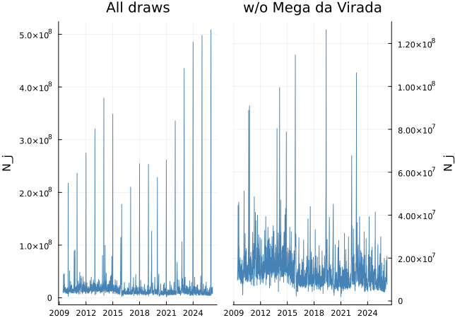

```julia
years = minimum(year.(df.date)):3:maximum(year.(df.date))
xtick_dates = Date.(years, 1, 1)
xtick_labels = string.(years)

# without mega da virada
df_less_mv = filter(row -> !(month(row.date) == 12 && day(row.date) == 31) &&
                            !(month(row.date) == 1  && day(row.date) == 1), df)

# plots
p1 = plot(df.date, df.n_tickets,
    ylabel = "N_j",
    title = "All draws",
    legend = false,
    xticks = (xtick_dates, xtick_labels),
    linecolor = :steelblue)

p2 = plot(df_less_mv.date, df_less_mv.n_tickets,
    ylabel = "N_j",
    title = "w/o Mega da Virada",
    legend = false,
    ymirror = true,
    xticks = (xtick_dates, xtick_labels),
    linecolor = :steelblue)

plot(p1, p2, layout = (1, 2))

#savefig("output/number_players.png")
```

In the first graph, note the clear seasonal pattern. The number of tickets sold spikes around the end of each year, when Caixa offers the special *Mega da Virada* - usually the highest prize of the year - and falls right after. When we exclude these observations, participation is considerably less volatile. The average number of tickets (or players, following our assumptions) during this period is 14.95 millions.

## (c)

**Expected prize for each draw.**

The expected prize per ticket is computed as the total amount paid out across all prize tiers - 4, 5, 6 correct numbers - divided by the total number of tickets sold in that draw. In math terms,

$$\mathbb{E}[Y_j] = \frac{G6_j}{N_j}Y^{6}_{j} + \frac{G5_j}{N_j}Y^{5}_{j} + \frac{G4_j}{N_j}Y^{4}_{j}$$

where $G\theta_j$ is the number of individuals who won one of the prizes, depending on the number $\theta \in \{4,5,6\}$ of numbers they got right, and $Y_j^{\theta}$ is the corresponding prize paid to each winner.

```julia
# G6/Nj * Y6 + G5/Nj * Y5 + G4/Nj * Y4
df[!, :total_prize] = (
    (df.ganhadores_6_acertos .* df.rateio_6_acertos) .+
    (df.ganhadores_5_acertos .* df.rateio_5_acertos) .+
    (df.ganhadores_4_acertos .* df.rateio_4_acertos)
)

# dividing by N_j
df[!, :exp_prize] = df.total_prize ./ df.n_tickets;

println("The expected prize across draws is: ", mean(df.exp_prize))
```

```
The expected prize across draws is: 0.9163787340084389
```

## (d)

**Expected return of buying a ticket.**

Finally, we compute the expected return. To do so, we divide the expected prize by the ticket price:
$$R_j = \frac{\mathbb{E}[Y_j]}{p_j}$$

```julia
# R = E[Y_j]/p_j
df[!, :exp_return] = df.exp_prize ./ df.preco;

println("The expected return across draws is: ", mean(df.exp_return))
```

```
The expected return across draws is: 0.2574797749504481
```

## (e)

**Analyzing the average return for a given prize announcement.**

The final step is to evaluate the average return for a given prize announcement:
$$\mathbb{E}[R_j | P_j]$$

The unconditional expected return considering all games after 2009 is 0.26. This means that, on average, each R$1 invested in a ticket returns only 26 cents.

Since this is only an average result, let us now evaluate the dispersion of expected returns given the announced prize. In the graph below, each dot is a draw. We restrict the range of prize values to highlight the underlying relationship.

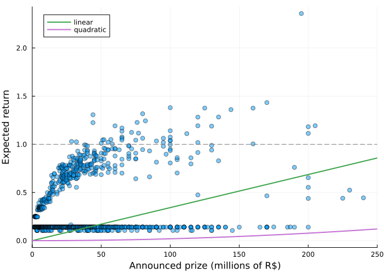

```julia
sort!(df, :prize_ann)

# OLS
# lin
reg_lin  = lm(@formula(exp_return ~ prize_ann), df)
# quad
df.prize_ann_sq = df.prize_ann .^ 2
reg_quad = lm(@formula(exp_return ~ prize_ann + prize_ann_sq), df)

# fit
x_range = range(0, 250e6, length=200)
df_pred = DataFrame(
    prize_ann = x_range,
    prize_ann_sq = x_range .^ 2)

y_pred_lin  = predict(reg_lin, df_pred)
y_pred_quad = predict(reg_quad, df_pred)

# plot
plot(df.prize_ann ./ 1e6, df.exp_return,
    xlims = (0, 250),
    seriestype = :scatter,
    alpha = 0.5,
    xlabel = "Announced prize (millions of R\$)",
    ylabel = "Expected return",
    label = false)
hline!([1.0], color = :gray, linestyle = :dash, label = false)

# OLS lines
plot!(x_range ./ 1e6, y_pred_lin, linewidth = 2, label = "linear")
plot!(x_range ./ 1e6, y_pred_quad, linewidth = 2, label = "quadratic")

#savefig("output/scatter_prize_return.png")
```

We observe two different sets of draws. While many draws align in some type of quadratic relation, others present very low expected returns regardless of the prize. Besides, only a few draws exhibit return greater than one. Once we remove outliers, the quadratic relationship and the “advantageous” returns vanish (check the graph below).

The result is that both linear and quadratic OLS specifications provide poor fit.

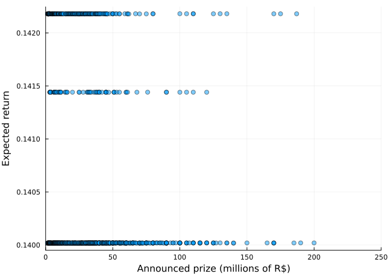

```julia
Q1 = quantile(df.exp_return, 0.25)
Q3 = quantile(df.exp_return, 0.75)
IQR = Q3 - Q1

df_no_outliers = filter(row -> row.exp_return >= Q1 - 1.5 * IQR && row.exp_return <= Q3 + 1.5 * IQR, df)

plot(df_no_outliers.prize_ann ./ 1e6, df_no_outliers.exp_return,
    xlims = (0, 250),
    seriestype = :scatter,
    alpha = 0.5,
    label = false,
    xlabel = "Announced prize (millions of R\$)",
    ylabel = "Expected return")

#savefig("output/scatter_prize_return_less_outlier.png")
```

Therefore, we adopt a simpler strategy. Below, we group the draws according to prize (ranges of R$25 million) and calculate the average return for each bin. The resulting graph gives an idea of the relationship between the variables.

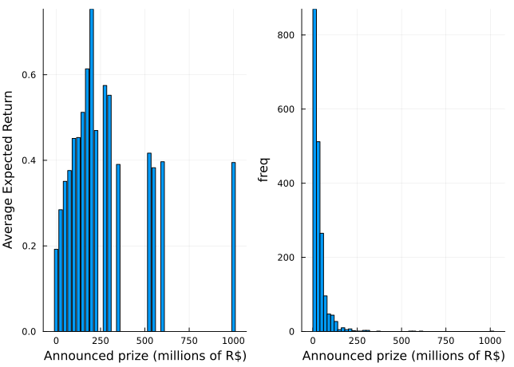

```julia
# bin strategy
bin_size = 25e6
df[!, :prize_bin] = floor.(df.prize_ann ./ bin_size) .* bin_size

df_bins = combine(groupby(df, :prize_bin),
    :exp_return => mean => :avg_return)

p3 = plot(df_bins.prize_bin ./ 1e6, df_bins.avg_return,
    seriestype = :bar,
    xlabel = "Announced prize (millions of R\$)",
    ylabel = "Average Expected Return",
    label = false)

#savefig(p3, "output/bin_analysis.png")

p4 = histogram(df.prize_ann ./ 1e6,
    bins = 50,
    xlabel = "Announced prize (millions of R\$)",
    ylabel = "freq",
    label = false)

#savefig(p4, "output/histogram_prizes.png")

plot(p3, p4, layout = (1,2))
```

Overall, it seems that the function of expected return given the announced prize is somewhat concave. At first, as the prize increases, return increases, since total revenue expands faster than the number of players. However, once the number of participants is “high enough”, individual expected gains fall considerably.

The histogram shows how right skewed the distribution of prizes is, which is explained mostly by the highest prizes in *Mega da Virada*. This helps account for the dispersion of draws we found before - there are very few observations with the highest prizes.

What is clear is that there is no range of announced prize presenting an average return above one.